# Determine Scholarship Awardee with Fuzzy Logic

Wisnu Adi Nurcahyo

October 31st, 2018

## Problem Description

Given 100 families head with their income (monthly) and their debt respectively from `DataTugas2.csv` in millions Indonesian Rupiah (IDR). Determine top 20 families whose would receive a scholarship with **fuzzy logic**.

## Implementation

### Collecting Data

Let’s read `DataTugas2.csv` file and re-format it so it would be more readable.

```r
# Read DataTugas2.csv and convert it to a List
data <- read.csv(file = "DataTugas2.csv", header = TRUE, sep = ",")

# Rename its columns so it would be more readable
names(data) <- c("number", "income", "debt")

# Preview
data
```

| number | income | debt |
| --- | --- | --- |
| 1 | 1.632 | 39.375 |
| 2 | 0.825 | 39.236 |
| 3 | 1.273 | 80.701 |
| 4 | 1.534 | 73.641 |
| 5 | 1.596 | 37.319 |
| 6 | 0.664 | 63.226 |
| 7 | 1.680 | 37.761 |
| 8 | 0.925 | 0.000 |
| 9 | 0.806 | 69.192 |
| 10 | 1.178 | 26.359 |

[output cut: 90 more lines]

How it looks in scatter plot?

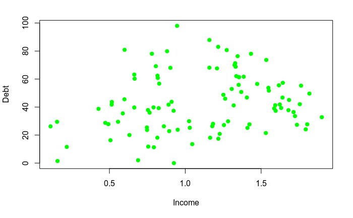

```r
# Using Scattersplot with green dots color
plot(x = data$income, y = data$debt, xlab = "Income", ylab = "Debt", col = "green", pch = 19)
```

### Linguistic Variables and Membership Functions

Now, determine a linguistic variable so we could classify them easily.

#### Income

We will use **low**, **moderate**, and **high**. As for the distribution, looks below.

Let,

- $X$ be the income in millions IDR
- 0.0 is the minimum income
- 2.0 is the maximum income

$$\ \ \ \ \ \ \ \ \ \ \ \ \ low := 0.0 \leq X \leq 0.8\\
modereate := 0.7 \leq X \leq 1.5\\
\ \ \ \ \ \ \ \ \ \ \ high := 1.3 \leq X \leq 2.0$$

```r
# Create a calculation function
f <- (function(x, m, var) exp(-(x - m) ** 2 / 2 * var ** 2))
# Building low income membership functions
income_low <- function(x) {
  med <- median(seq(0.0, 0.8, by = 0.05))
  var_total <- 3
  return(f(x, med, var_total))
}
# Building moderate income membership functions
income_moderate <- function(x) {
  med <- median(seq(0.7, 1.5, by = 0.05))
  var_total <- 3
  return(f(x, med, var_total))
}
# Building high income membership functions
income_high <- function(x) {
  med <- median(seq(1.3, 2.0, by = 0.05))
  var_total <- 3
  return(f(x, med, var_total))
}
# Generating plot for distribution preview
income_matrix <- matrix(data = seq(0.0, 2.0, by = 0.05))
plot(income_matrix, income_low(income_matrix), type = "l", col = "green", xlab = "income", ylab = "fuzzy set")
lines(income_matrix, income_moderate(income_matrix), col = "orange")
```

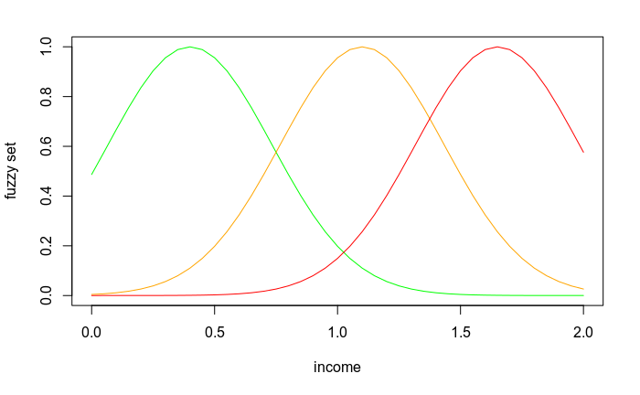

```r
lines(income_matrix, income_high(income_matrix), col = "red")
```

#### Debt

We will use **small**, **medium**, and **big**. As for the distribution, looks below.

Let,

- $X$ be the debt in millions IDR
- 0 is the minimum debt
- 100 is the maximum debt

$$\ \ small := 0 \leq X \leq 30\\
medium := 20 \leq X \leq 65\\
\ \ \ \ \ \ \ \ \ \ \ big := 50 \leq X \leq 100$$

```r
# Building small debt membership functions
debt_small <- function(x) {
  med <- median(0:30)
  var_total <- 0.04
  return(f(x, med, var_total))
}
# Building medium debt membership functions
debt_medium <- function(x) {
  med <- median(20:65)
  var_total <- 0.09
  return(f(x, med, var_total))
}
# Building big dept membership functions
debt_big <- function(x) {
  med <- median(50:100)
  var_total <- 0.05
  return(f(x, med, var_total))
}
# Generating plot for distribution preview
debt_matrix <- matrix(data = seq(0, 100, by = 1))
plot(debt_matrix, debt_small(debt_matrix), type = "l", col = "green", xlab = "debt", ylab = "fuzzy set")
lines(debt_matrix, debt_medium(debt_matrix), col = "orange")
```

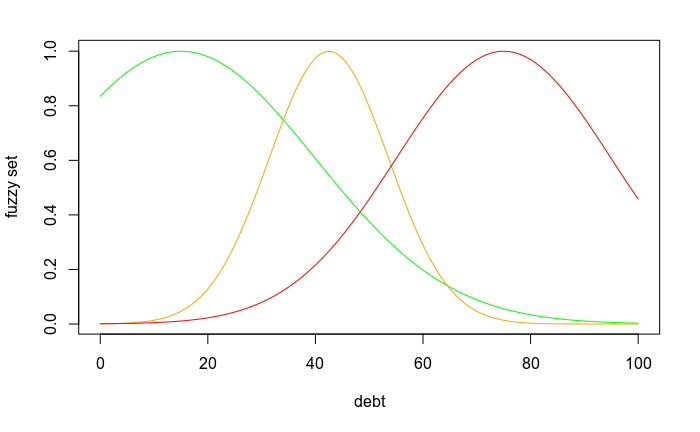

```r
lines(debt_matrix, debt_big(debt_matrix), col = "red")
```

#### Acceptance

We will use **accepted** and **declined**.

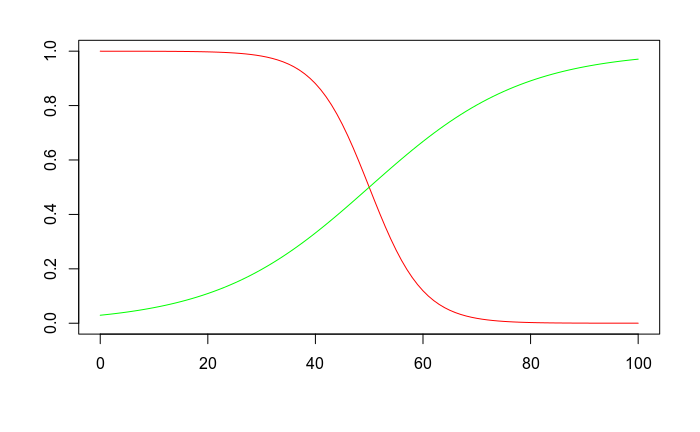

```r
# Building an acceptance accepted membership function
acceptance_accepted <- function(x) {
  var <- 0.07
  x <- x - 50
  x <- x * var
  return((1) / (1 + exp(-x)))
}

# Building an acceptance declined membership function
acceptance_declined <- function(x) {
  var <- 0.2
  x <- x - 50
  x <- x * var
  return((1) / (1 + exp(x)))
}

# Initialize accpetance matrix for distribution preview
acceptance_matrix <- matrix(data = seq(0, 100, by = 1))

# Filling up acceptance matrix for accepted families
acceptance_accepted_matrix <- c()
for (x in acceptance_matrix) {
  acceptance_accepted_matrix <- c(acceptance_accepted_matrix, acceptance_accepted(x))
}

# Filling up acceptance matrix for declined families
acceptance_declined_matrix <- c()
for (x in acceptance_matrix) {
  acceptance_declined_matrix <- c(acceptance_declined_matrix, acceptance_declined(x))
}

# Distribution preview
plot(acceptance_matrix, acceptance_declined_matrix, type = "l", col = "red", xlab = "", ylab = "")
lines(acceptance_matrix, acceptance_accepted_matrix, col = "green")
```

### Fuzzy Rule

Now, we define a fuzzy rules. This is based on linguistic variables above.

```r
# Define acceptance
acceptance_sequence <- c("accepted", "accepted", "accepted", "accepted", "declined", "declined", "declined", "declined", "declined")

# Convert acceptance into a matrix
fuzzy_rule <- matrix(acceptance_sequence, nrow = 3, ncol = 3, byrow = TRUE)

# Rename them all
colnames(fuzzy_rule) <- c("debt_small", "debt_medium", "debt_big")
rownames(fuzzy_rule) <- c("income_low", "income_moderate", "income_high")

# Preview
fuzzy_rule
```

```
                debt_small debt_medium debt_big
income_low      "accepted" "accepted"  "accepted"
income_moderate "accepted" "declined"  "declined"
income_high     "declined" "declined"  "declined"
```

### Fuzzification

To put it simply, we take the data and put them to each membership functions we already made above.

```r
# Initialize linguistic variables
income_low_list <- c()
income_moderate_list <- c()
income_high_list <- c()
debt_small_list <- c()
debt_medium_list <- c()
debt_big_list <- c()
# Disable scientific notation
options(scipen = 100)
# Apply each membership functions
for (income in data$income) {
  income_low_list <- c(income_low_list, income_low(income))
  income_moderate_list <- c(income_moderate_list, income_moderate(income))
  income_high_list <- c(income_high_list, income_high(income))
}
for (debt in data$debt) {
  debt_small_list <- c(debt_small_list, debt_small(debt))
  debt_medium_list <- c(debt_medium_list, debt_medium(debt))
  debt_big_list <- c(debt_big_list, debt_big(debt))
}
# Building a data frame
fuzzy_value <- data.frame(
  row.names = 1:100,

  income_low = income_low_list,
  income_moderate = income_moderate_list,
  income_high = income_high_list,

  debt_small = debt_small_list,
  debt_medium = debt_medium_list,
  debt_big = debt_big_list
)
# Preview
fuzzy_value
```

|  | income_low | income_moderate | income_high | debt_small | debt_medium | debt_big |
| --- | --- | --- | --- | --- | --- | --- |
| 1 | 0.0010806333 | 0.27982021 | 0.99854306237 | 0.621690748 | 0.961221140740 | 0.2046557906 |
| 2 | 0.4436086607 | 0.71154793 | 0.04675600885 | 0.625060423 | 0.957770138439 | 0.2021329520 |
| 3 | 0.0324005299 | 0.87399511 | 0.52751366962 | 0.031641140 | 0.002711559295 | 0.9601874518 |
| 4 | 0.0030677773 | 0.42844110 | 0.94124482302 | 0.063863103 | 0.019692141764 | 0.9976940615 |
| 5 | 0.0016014081 | 0.33052532 | 0.98696371810 | 0.671319427 | 0.896987652766 | 0.1695135861 |
| 6 | 0.7307879086 | 0.42509951 | 0.01258962773 | 0.155579619 | 0.175564872975 | 0.8408988960 |
| 7 | 0.0006281070 | 0.22007211 | 0.99595819019 | 0.660703240 | 0.913058441482 | 0.1766775602 |
| 8 | 0.2892937995 | 0.87126204 | 0.09391994580 | 0.835270211 | 0.000665273383 | 0.0008838263 |
| 9 | 0.4762739810 | 0.67776002 | 0.04053814080 | 0.095424655 | 0.055828287188 | 0.9587105447 |
| 10 | 0.0656263491 | 0.97299338 | 0.36695061647 | 0.901927170 | 0.348138768703 | 0.0519520760 |

[output cut: 90 more lines]

## Inference

```r
# Building an inference for fuzzy_output
inference <- function(data) {
  data <- as.vector(data)
  income_keys <- c("income_low", "income_moderate", "income_high")
  income <- data[income_keys]

  debt_keys <- c("debt_small", "debt_medium", "debt_big")
  debt <- data[debt_keys]

  result <- list(accepted = c(), declined = c())

  for (income_key in income_keys) {
    for (debt_key in debt_keys) {
      inference_key <- fuzzy_rule[income_key,][[debt_key]]
      inference_val <- min(data[income_key], data[debt_key])
      result[[inference_key]] <- c(result[[inference_key]], inference_val)
    }
  }

  result$accepted <- max(result$accepted)
  result$declined <- max(result$declined)

  return(result)
}
# Apply inference to each fuzzy_value
fuzzy_output <- list(accepted = c(), declined = c())
for (index in 1:100) {
  infer <- inference(fuzzy_value[index,])
  fuzzy_output$accepted <- c(fuzzy_output$accepted, infer$accepted)
  fuzzy_output$declined <- c(fuzzy_output$declined, infer$declined)
}
# Convert fuzzy_output into a data frame
fuzzy_output <- data.frame(row.names = 1:100, accepted = fuzzy_output$accepted, declined = fuzzy_output$declined)
# Preview
fuzzy_output
```

|  | accepted | declined |
| --- | --- | --- |
| 1 | 0.27982021 | 0.961221141 |
| 2 | 0.62506042 | 0.711547929 |
| 3 | 0.03240053 | 0.873995109 |
| 4 | 0.06386310 | 0.941244823 |
| 5 | 0.33052532 | 0.896987653 |
| 6 | 0.73078791 | 0.425099508 |
| 7 | 0.22007211 | 0.913058441 |
| 8 | 0.83527021 | 0.093919946 |
| 9 | 0.47627398 | 0.677760024 |
| 10 | 0.90192717 | 0.366950616 |

[output cut: 90 more lines]

## Defuzzification

```r
defuzzification <- function(data) {
  data_point <- seq(1, 100, by = 1)
  data_value <- c()

  for (point in data_point) {
    accepted <- min(acceptance_accepted(point), data$accepted)
    declined <- min(acceptance_declined(point), data$declined)

    data_value <- c(data_value, max(accepted, declined))
  }

  return(sum(data_point * data_value) / (sum(data_value)))
}
acceptance_data <- c()
for (index in 1:100) {
  output <- fuzzy_output[index,]
  acceptance_data <- c(acceptance_data, defuzzification(output))
}
acceptance_data <- data.frame(row.names = 1:100, acceptance = acceptance_data)
acceptance_data
```

|  | acceptance |
| --- | --- |
| 1 | 36.42544 |
| 2 | 48.85969 |
| 3 | 28.02586 |
| 4 | 28.81721 |
| 5 | 38.73385 |
| 6 | 57.13745 |
| 7 | 34.96194 |
| 8 | 67.88166 |
| 9 | 46.11373 |
| 10 | 61.01682 |

[output cut: 90 more lines]

## Post Processing

```r
data$acceptance <- acceptance_data$acceptance
data
```

| number | income | debt | acceptance |
| --- | --- | --- | --- |
| 1 | 1.632 | 39.375 | 36.42544 |
| 2 | 0.825 | 39.236 | 48.85969 |
| 3 | 1.273 | 80.701 | 28.02586 |
| 4 | 1.534 | 73.641 | 28.81721 |
| 5 | 1.596 | 37.319 | 38.73385 |
| 6 | 0.664 | 63.226 | 57.13745 |
| 7 | 1.680 | 37.761 | 34.96194 |
| 8 | 0.925 | 0.000 | 67.88166 |
| 9 | 0.806 | 69.192 | 46.11373 |
| 10 | 1.178 | 26.359 | 61.01682 |

[output cut: 90 more lines]

```r
accepted_families <- rev(order(data$acceptance))[1:20]
#declined_families <- data$acceptance[!(accepted_families %in% 1:100)]
plot(data[accepted_families,]$income, data[accepted_families,]$debt, col = "green", pch = 19, xlab = "income", ylab = "debt")
par(new = TRUE)
```

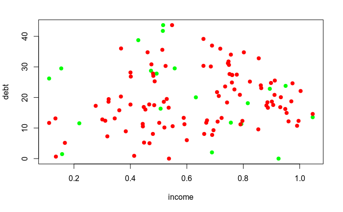

```r
plot(data$income, data$debt, col = "red", pch = 19, axes = FALSE, xlab = "", ylab = "")
```